# datamining-2020f homework1

### (c)

Are any of the predictors associated with per capita crime rate? If so, explain the relationship.

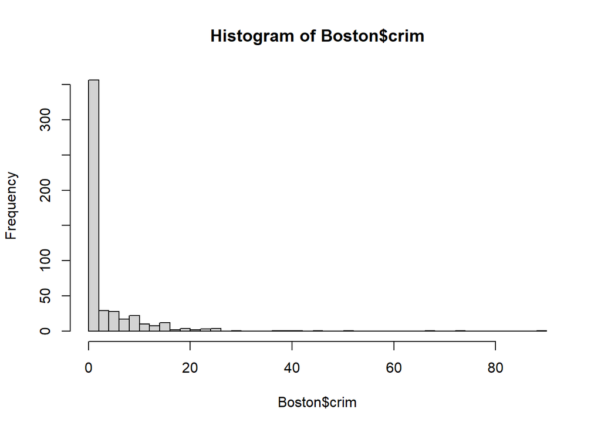

```r
hist(Boston$crim, breaks = 50)
```

* 대부분의 교외 지역에서는 범죄가 없다. (데이터의 80%가 범죄율 발생의 20 아래로 떨어진다.)

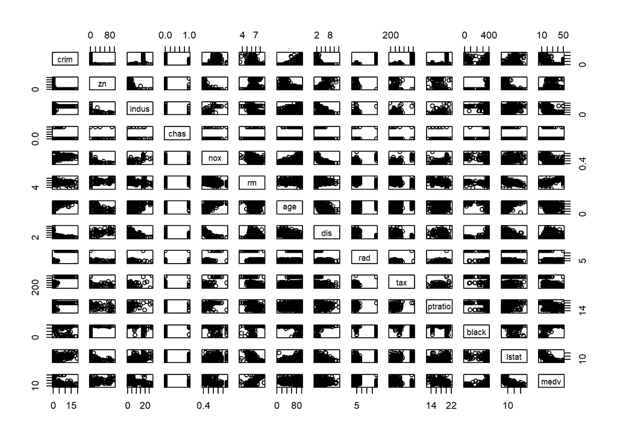

```r
pairs(Boston[Boston$crim < 20, ])
```

* 범죄율과 일산화질소 농도. 주택당 방수, 1940년 이전에 지어진 주택 비율, 직업센터의 거리, 인구 중 하위 계층 비율 그리고 중간값까지 관계가 있을 것으로 추정된다.

### (d)

Do any of the suburbs of Boston appear to have particularly high crime rates ? Tax rates ? Pupil-teacher ratios ?

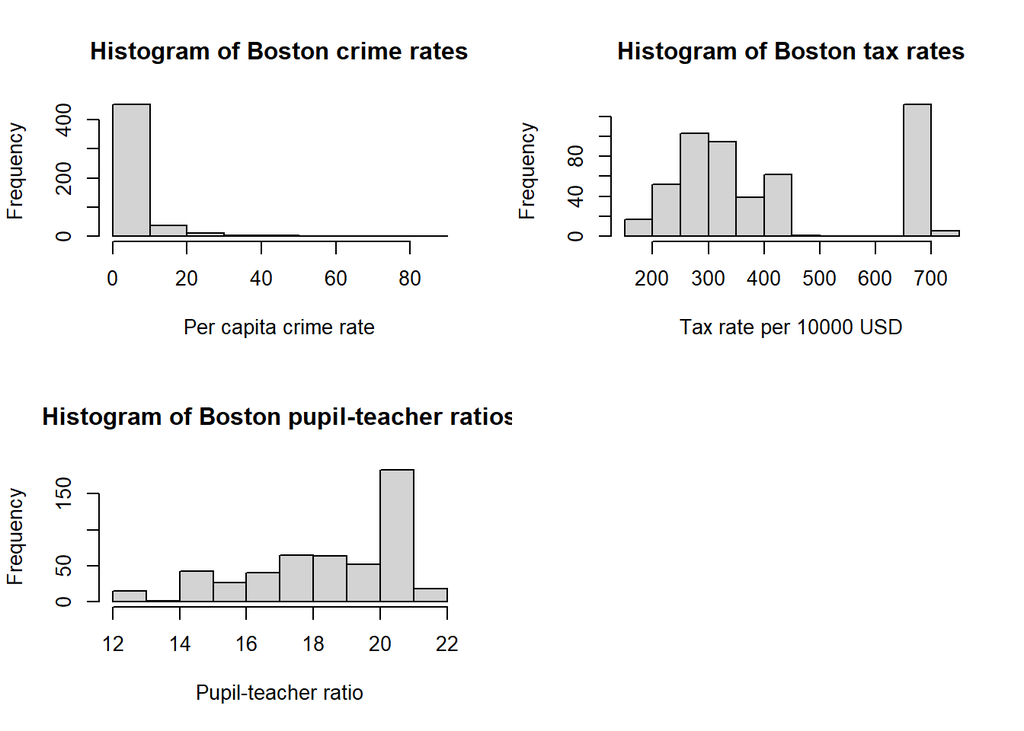

```r
par(mfrow = c(2, 2))
hist(Boston$crim, xlab = "Per capita crime rate", main = "Histogram of Boston crime rates")
hist(Boston$tax, xlab = "Tax rate per 10000 USD", main = "Histogram of Boston tax rates")
hist(Boston$ptratio, xlab = "Pupil-teacher ratio", main = "Histogram of Boston pupil-teacher ratios")
```

- 범죄율: 대부분의 교외 지역이 범죄율이 0에 가깝거나 0이라는 것을 알지만, 일부의 교외지역은 범죄율이 매우 높다.
- Tax Rates: 대부분은 비슷한 tax 비율을 가지지만, tax rate가 멀리 떨어져있는 것도 존재한다.
- Ptratio: 크게 특이한 점이나 간격이 없는 것으로 보이며 더 작은 범위를 초과한다.

```r
summary(Boston[, c(1, 10, 11)])
```

```
##       crim               tax           ptratio
##  Min.   : 0.00632   Min.   :187.0   Min.   :12.60
##  1st Qu.: 0.08205   1st Qu.:279.0   1st Qu.:17.40
##  Median : 0.25651   Median :330.0   Median :19.05
##  Mean   : 3.61352   Mean   :408.2   Mean   :18.46
##  3rd Qu.: 3.67708   3rd Qu.:666.0   3rd Qu.:20.20
##  Max.   :88.97620   Max.   :711.0   Max.   :22.00
```

히스토그램과 수치해석에 따르면, Boston에서는 범죄율, 세율, 학생과 교사 비율이 높은 것을 볼 수 있다. 최소 범죄율은 0.00632이며, 최대 범죄율은 88.97620이며, 중간값은 0.25651이다. 최저 세율은 10000달러 당 187달러인 반면, 최고 세율은 711달러로 중간값은 330원이다. 학생-교사 비율의 최소비율은 교사 1인당 12.60명인 반면, 최대 학생 비율은 22명으로 중간값은 19.05명이다. 중간값을 고려한다면, 데이터 집합의 최대 학생-교사 비율은 높지 않다. 왜냐하면 약 절반이 19 혹은 그 이상의 비율을 가지고 있기 때문이다.

### (e)

How many of the suburbs in this data set bound the Charles river?

```r
table(Boston$chas)
```

```
##
##   0   1
## 471  35
```

35개의 교외지역이 Charles 강으로 둘러쌓여있다.

### (f)

What is the median pupil-teacher ratio among the towns in this data set?

```r
summary(Boston$ptratio)
```

```
##    Min. 1st Qu.  Median    Mean 3rd Qu.    Max.
##   12.60   17.40   19.05   18.46   20.20   22.00
```

마을 사이에 학생-교사의 비율은 교사 1인당 19.05명이다.

### (g)

Which suburb of Boston has lowest median value of owneroccupied homes? What are the values of the other predictors for that suburb, and how do those values compare to the overall ranges for those predictors? Comment on your findings.

```r
Boston[Boston$medv == min(Boston$medv), ]
```

```
##        crim zn indus chas   nox    rm age    dis rad tax ptratio  black lstat
## 399 38.3518  0  18.1    0 0.693 5.453 100 1.4896  24 666    20.2 396.90 30.59
## 406 67.9208  0  18.1    0 0.693 5.683 100 1.4254  24 666    20.2 384.97 22.98
##     medv
## 399    5
## 406    5
```

자가 소유 주택의 중간값(5)이 가장 낮은 교외가 두 곳에 해당한다.

```r
Boston_percentiles <- sapply(Boston[ ,-4], function(x) rank(x)/length(x))

Boston_percentiles[c(399, 406),]
```

```
##           crim        zn     indus       nox        rm      age        dis
## [1,] 0.9881423 0.3685771 0.7579051 0.8448617 0.0770751 0.958498 0.05731225
## [2,] 0.9960474 0.3685771 0.7579051 0.8448617 0.1363636 0.958498 0.04150198
##            rad       tax   ptratio     black     lstat        medv
## [1,] 0.8705534 0.8606719 0.7519763 0.8814229 0.9782609 0.002964427
## [2,] 0.8705534 0.8606719 0.7519763 0.3498024 0.8992095 0.002964427
```

가장 낮은 중간값을 가진 두 관측치가 유사한 값을 가지며, 많은 관측치들이 극단적인 값들을 가짐을 알 수 있다.

- 90th 이상 백분위수: crim, age, lstat
- 75th 이상 백분위수: indus, nox, rad, tax, ptratio
- 두 교외가 모두 chas = 0: charles 강 근처에 위치하지 않는다.
- 백분위수 감소: zn, rm, dis
- black은 관측치마다 88위수와 35분위수에서 다른 유일한 변수이다.

### (h)

In this data set, how many of the suburbs average more than seven rooms per dwelling? More than eight rooms per dwelling? Comment on the suburbs that average more than eight rooms per dwelling.

```r
#한 주거지당 7개 이상의 객실:
sum(Boston$rm > 7)
```

```
## [1] 64
```

```r
# 한 주거지당 8개 이상의 객실
Boston_gt_8rooms <- Boston[Boston$rm > 8, ]

nrow(Boston_gt_8rooms)
```

```
## [1] 13
```

```r
prop.table(table(Boston_gt_8rooms$chas))
```

```
##
##         0         1
## 0.8461538 0.1538462
```

- 약 15%의 집은 찰스 강 근처에 위치해 있다.

```r
summary(Boston_gt_8rooms)
```

```
##       crim               zn            indus             chas
##  Min.   :0.02009   Min.   : 0.00   Min.   : 2.680   Min.   :0.0000
##  1st Qu.:0.33147   1st Qu.: 0.00   1st Qu.: 3.970   1st Qu.:0.0000
##  Median :0.52014   Median : 0.00   Median : 6.200   Median :0.0000
##  Mean   :0.71879   Mean   :13.62   Mean   : 7.078   Mean   :0.1538
##  3rd Qu.:0.57834   3rd Qu.:20.00   3rd Qu.: 6.200   3rd Qu.:0.0000
##  Max.   :3.47428   Max.   :95.00   Max.   :19.580   Max.   :1.0000
##       nox               rm             age             dis
##  Min.   :0.4161   Min.   :8.034   Min.   : 8.40   Min.   :1.801
##  1st Qu.:0.5040   1st Qu.:8.247   1st Qu.:70.40   1st Qu.:2.288
##  Median :0.5070   Median :8.297   Median :78.30   Median :2.894
##  Mean   :0.5392   Mean   :8.349   Mean   :71.54   Mean   :3.430
##  3rd Qu.:0.6050   3rd Qu.:8.398   3rd Qu.:86.50   3rd Qu.:3.652
##  Max.   :0.7180   Max.   :8.780   Max.   :93.90   Max.   :8.907
##       rad              tax           ptratio          black
##  Min.   : 2.000   Min.   :224.0   Min.   :13.00   Min.   :354.6
##  1st Qu.: 5.000   1st Qu.:264.0   1st Qu.:14.70   1st Qu.:384.5
##  Median : 7.000   Median :307.0   Median :17.40   Median :386.9
##  Mean   : 7.462   Mean   :325.1   Mean   :16.36   Mean   :385.2
##  3rd Qu.: 8.000   3rd Qu.:307.0   3rd Qu.:17.40   3rd Qu.:389.7
##  Max.   :24.000   Max.   :666.0   Max.   :20.20   Max.   :396.9
##      lstat           medv
##  Min.   :2.47   Min.   :21.9
##  1st Qu.:3.32   1st Qu.:41.7
##  Median :4.14   Median :48.3
##  Mean   :4.31   Mean   :44.2
##  3rd Qu.:5.12   3rd Qu.:50.0
##  Max.   :7.44   Max.   :50.0
```

- summary를 보면 한 가구당 평균 8개의 방이 차지하는 공간이 범죄율이 낮고, 질산염의 농도가 낮으며, 흑인 거주자의 비율이 낮으며, 낮은 지위의 거주자의 비율이 전체 데이터 집합에 비해 낮다.